# Анализ пациентов, госпитализированных в больницу после получения черепно-мозговой травмы вследствие падения с электросамоката

2023-10-22

## 1. Дайте описательную статистику для переменных, включённых в датасет. Дополнительно рассчитайте, у какого количества пациентов и в каком проценте случаев у пациентов был снижен уровень гемоглобина? Используйте следующие референтные значения (Мужчины:13.5–16 г/дл, Женщины: 12–14 г/дл).

Загружаем датафрейм. Посмотрим описательную статистику.

```r
trauma <- read_excel('trauma.xlsx', range = cell_cols("B:M"))
trauma %>%
  summary()
```

```
##        id             Name               Sex                 Age
##  Min.   :   1.0   Length:1024        Length:1024        Min.   :18.00
##  1st Qu.: 256.8   Class :character   Class :character   1st Qu.:29.00
##  Median : 512.5   Mode  :character   Mode  :character   Median :41.00
##  Mean   : 512.5                                         Mean   :40.94
##  3rd Qu.: 768.2                                         3rd Qu.:53.00
##  Max.   :1024.0                                         Max.   :64.00
##     Height              Weight           SBP             DBP
##  Length:1024        Min.   :133.3   Min.   : 90.0   Min.   : 58.00
##  Class :character   1st Qu.:181.7   1st Qu.:106.0   1st Qu.: 78.00
##  Mode  :character   Median :193.9   Median :110.0   Median : 84.00
##                     Mean   :193.5   Mean   :110.8   Mean   : 84.78
##                     3rd Qu.:205.4   3rd Qu.:116.0   3rd Qu.: 90.00
##                     Max.   :253.1   Max.   :134.0   Max.   :110.00
##       FOUR             GSC               Hb           Death
##  Min.   : 0.000   Min.   : 3.000   Min.   : 0.0   Min.   :0.0000
##  1st Qu.: 7.000   1st Qu.: 6.000   1st Qu.:12.0   1st Qu.:0.0000
##  Median : 9.000   Median : 8.000   Median :13.1   Median :0.0000
##  Mean   : 8.853   Mean   : 7.785   Mean   :12.8   Mean   :0.3994
##  3rd Qu.:11.000   3rd Qu.:10.000   3rd Qu.:14.0   3rd Qu.:1.0000
##  Max.   :16.000   Max.   :14.000   Max.   :16.2   Max.   :1.0000
```

Приведем переменные к нужному формату.

```r
trauma <- trauma %>%
  mutate(id = as.factor(id),
         Sex = as.factor(Sex),
         Height = as.numeric(sub("\"", "", Height)),
         Death  = as.factor(Death),
         Hb = ifelse(Hb == 0, NA, Hb))
trauma %>%
  summary()
```

```
##        id           Name               Sex           Age            Height
##  1      :   1   Length:1024        Female:384   Min.   :18.00   Min.   :63.80
##  2      :   1   Class :character   Male  :640   1st Qu.:29.00   1st Qu.:69.70
##  3      :   1   Mode  :character                Median :41.00   Median :72.80
##  4      :   1                                   Mean   :40.94   Mean   :72.42
##  5      :   1                                   3rd Qu.:53.00   3rd Qu.:75.10
##  6      :   1                                   Max.   :64.00   Max.   :79.90
##  (Other):1018
##      Weight           SBP             DBP              FOUR
##  Min.   :133.3   Min.   : 90.0   Min.   : 58.00   Min.   : 0.000
##  1st Qu.:181.7   1st Qu.:106.0   1st Qu.: 78.00   1st Qu.: 7.000
##  Median :193.9   Median :110.0   Median : 84.00   Median : 9.000
##  Mean   :193.5   Mean   :110.8   Mean   : 84.78   Mean   : 8.853
##  3rd Qu.:205.4   3rd Qu.:116.0   3rd Qu.: 90.00   3rd Qu.:11.000
##  Max.   :253.1   Max.   :134.0   Max.   :110.00   Max.   :16.000
##
##       GSC               Hb        Death
##  Min.   : 3.000   Min.   : 9.40   0:615
##  1st Qu.: 6.000   1st Qu.:12.10   1:409
##  Median : 8.000   Median :13.10
##  Mean   : 7.785   Mean   :13.01
##  3rd Qu.:10.000   3rd Qu.:14.00
##  Max.   :14.000   Max.   :16.20
##                   NA's   :16
```

Рассчитываем, у какого количества пациентов и в каком проценте случаев у пациентов был снижен уровень гемоглобина. Референтные значения (Мужчины: 13.5–16 г/дл, Женщины: 12–14 г/дл).

```r
n_male <- trauma %>%
  filter(Sex == 'Male') %>%
  filter(!is.na(Hb)) %>%
  nrow()
Hb_low_male <- trauma %>%
  filter(Sex == 'Male') %>%
  filter(!is.na(Hb)) %>%
  filter(Hb <= 13.5) %>%
  nrow()
n_female <- trauma %>%
  filter(Sex == 'Female') %>%
  filter(!is.na(Hb)) %>%
  nrow()
Hb_low_female <- trauma %>%
  filter(Sex == 'Female') %>%
  filter(!is.na(Hb)) %>%
  filter(Hb <= 12) %>%
  nrow()

data.frame(n_male = Hb_low_male,
           p_male = round(Hb_low_male/n_male, 2),
           n_female = Hb_low_female,
           p_female = round(Hb_low_female/n_female, 2))
```

```
##   n_male p_male n_female p_female
## 1    259   0.41      240     0.64
```

## 2. Рассчитайте индекс массы тела у пациентов (кг / м2). Каков был средний (M (SD)) уровень ИМТ у пациентов, включённых в исследование? Какая доля пациентов имела ожирение (ИМТ> 30)?

Рассчитываю индекс массы тела (BMI). Посмотрим, какое среднее значение ИМТ у пациентов, включённых в исследование.

```r
trauma <- trauma %>%
  mutate(BMI = (Weight / 2.2) / ((Height * 0.0254) ** 2))

mean_bmi <- mean(trauma$BMI, na.rm = TRUE)
sd_bmi <- sd(trauma$BMI, na.rm = TRUE)

data.frame(
  Mean_BMI = round(mean_bmi, 2),
  SD_BMI = round(sd_bmi, 2)
)
```

```
##   Mean_BMI SD_BMI
## 1    26.06   2.57
```

Рассчитываю долю пациентов с ожирением (ИМТ> 30).

```r
n <- trauma %>%
  nrow()
n_obese <- trauma %>%
  filter(BMI > 30) %>%
  nrow()
round(n_obese / n, 4)
```

```
## [1] 0.0693
```

## 3. Как выглядит ROC-кривая для предсказания летального исхода в течение 24 часов по переменной, характеризующей уровень гемоглобина? Постройте график. Чем может быть обусловлена такая форма кривой?

См. ниже

## 4. Чему равна площадь под ROC-кривой, которую вы построили в вопросе 3? Чему равен 95% двусторонний ДИ для площади под ROC-кривой, которую вы построили в вопросе 3?

Создадим ROC-кривую и посмотрим 95% доверительнй интервал.

```r
library(pROC)
roc_curve_HB <- roc(Death ~ Hb, data=trauma, ci = T)
roc_curve_HB
```

```
##
## Call:
## roc.formula(formula = Death ~ Hb, data = trauma, ci = T)
##
## Data: Hb in 605 controls (Death 0) > 403 cases (Death 1).
## Area under the curve: 0.7078
## 95% CI: 0.6763-0.7392 (DeLong)
```

Доверительный интервал 95% для ROC-кривой: 0.6763-0.7392.

Построим ROC-кривую, добавив площадь под ней.

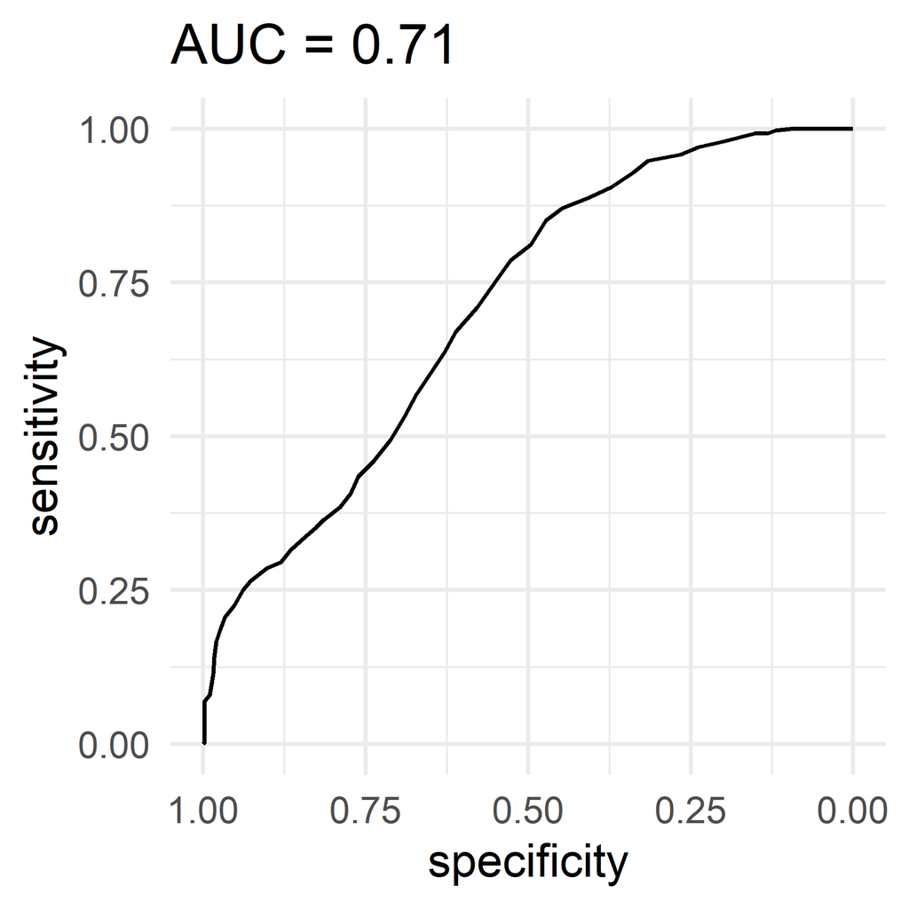

```r
roc_curve_HB %>%
  ggroc() +
  ggtitle(paste0('AUC = ', round(roc_curve_HB$auc, 2))) +
  theme_minimal()
```

Площадь под ROC-кривой равна 0.71, что не очень хорошо. Форма кривой тоже далека от идеальной. Это определяется бимодальностью распределения (подсказка от преподавателя).

Построим отдельно для мужчин.

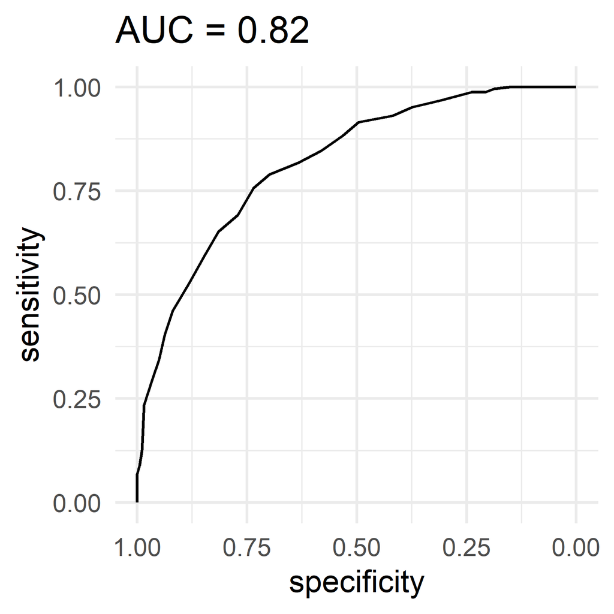

```r
trauma_male <- trauma %>%
  filter(Sex=='Male')
roc_curve_HB_male <- roc(Death ~ Hb, data=trauma_male, ci = T)
roc_curve_HB_male %>%
  ggroc() +
  ggtitle(paste0('AUC = ', round(roc_curve_HB_male$auc, 2))) +
  theme_minimal()
```

Построим отдельно для женщин.

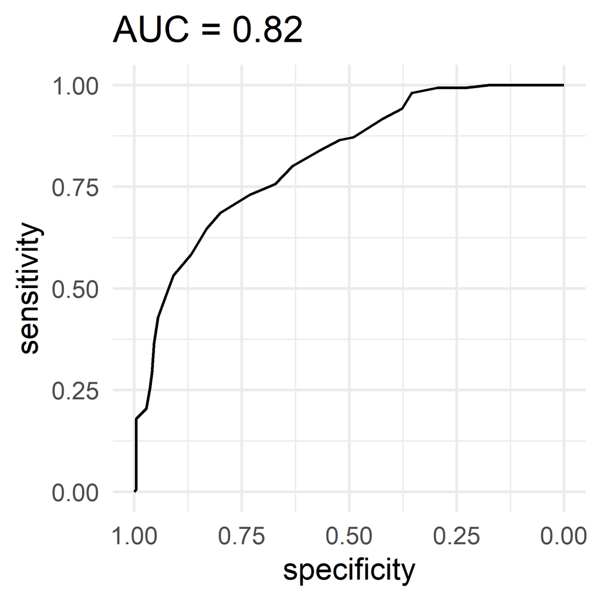

```r
trauma_female <- trauma %>%
  filter(Sex=='Female')
roc_curve_HB_female <- roc(Death ~ Hb, data=trauma_female, ci = T)
roc_curve_HB_female %>%
  ggroc() +
  ggtitle(paste0('AUC = ', round(roc_curve_HB_female$auc, 2))) +
  theme_minimal()
```

## 5. Проведите ROC-анализ и определите, какое пороговое значение является оптимальным для предсказания летального исхода в течение 24 часов по шкале комы Глазго. Какой чувствительностью и специфичностью обладает данный порог?

Проведем ROC-анализ предсказания летального исхода по шкале комы Глазго.

```r
library(pROC)
roc_curve_GSC <- roc(Death ~ GSC, data=trauma, ci = T)
roc_curve_GSC
```

```
##
## Call:
## roc.formula(formula = Death ~ GSC, data = trauma, ci = T)
##
## Data: GSC in 615 controls (Death 0) > 409 cases (Death 1).
## Area under the curve: 0.9124
## 95% CI: 0.8959-0.9289 (DeLong)
```

Построим ROC-кривую.

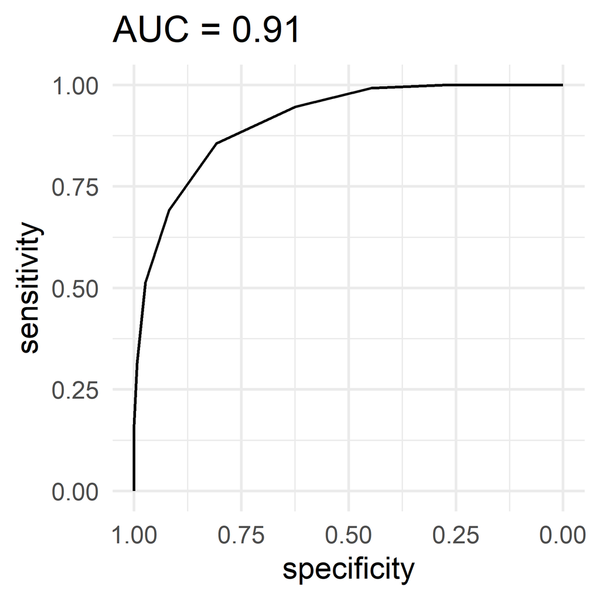

```r
roc_curve_GSC %>%
  ggroc() +
  ggtitle(paste0('AUC = ', round(roc_curve_GSC$auc, 2))) +
  theme_minimal()
```

Определим пороговое значение по методу closest.topleft, чувствительность и специфичность для данного критерия.

```r
roc_curve_GSC %>% coords(x = "best", best.method = "closest.topleft")
```

```
##   threshold specificity sensitivity
## 1       7.5   0.8081301   0.8557457
```

## 6. Какая из количественных переменных в датасете (включая рассчитанный вами ранее ИМТ) обладает наибольшей площадью под ROC-кривой? Как вы можете интерпретировать это знание? Какая количественная переменная имеет наименьшую площадь?

Проведем ROC-анализ дял всех количественных переменных.

```r
trauma %>% names()
```

```
##  [1] "id"     "Name"   "Sex"    "Age"    "Height" "Weight" "SBP"    "DBP"
##  [9] "FOUR"   "GSC"    "Hb"     "Death"  "BMI"
```

```r
trauma %>%
    select(Death | is.numeric) %>% # выберем колонку Death и все колонки numeric
    pivot_longer(cols = !Death) %>%
    group_by(name) %>%
    summarise(AUC = roc(Death, value, ci = T)$ci[2] %>% round(3),
              AUC_LCL = roc(Death, value, ci = T)$ci[1] %>% round(3),
              AUC_UCL = roc(Death, value, ci = T)$ci[3] %>% round(3)) %>%
  arrange(-AUC)
```

```
## # A tibble: 9 × 4
##   name     AUC AUC_LCL AUC_UCL
##   <chr>  <dbl>   <dbl>   <dbl>
## 1 FOUR   0.934   0.92    0.948
## 2 GSC    0.912   0.896   0.929
## 3 SBP    0.786   0.759   0.814
## 4 DBP    0.744   0.714   0.774
## 5 Hb     0.708   0.676   0.739
## 6 Age    0.527   0.491   0.563
## 7 Weight 0.518   0.482   0.554
## 8 BMI    0.502   0.465   0.538
## 9 Height 0.482   0.445   0.518
```

Переменная FOUR имеет большую площать под ROC-кривой, следовательно балл по шкале комы FOUR при поступлении является наилучшим предиктором летального исхода.

Height имеет наименьшую площадь под кривой (0.482). Исходя из этого ИМТ является случайной диагностикой летального исхода.